# Optimization Journey

Claus Brenner, 17.12.2020.

# Fitting a model - first, in 1D

## Least squares estimation in 1D

Say we are given these points $b_1, b_2, b_3, b_4$:

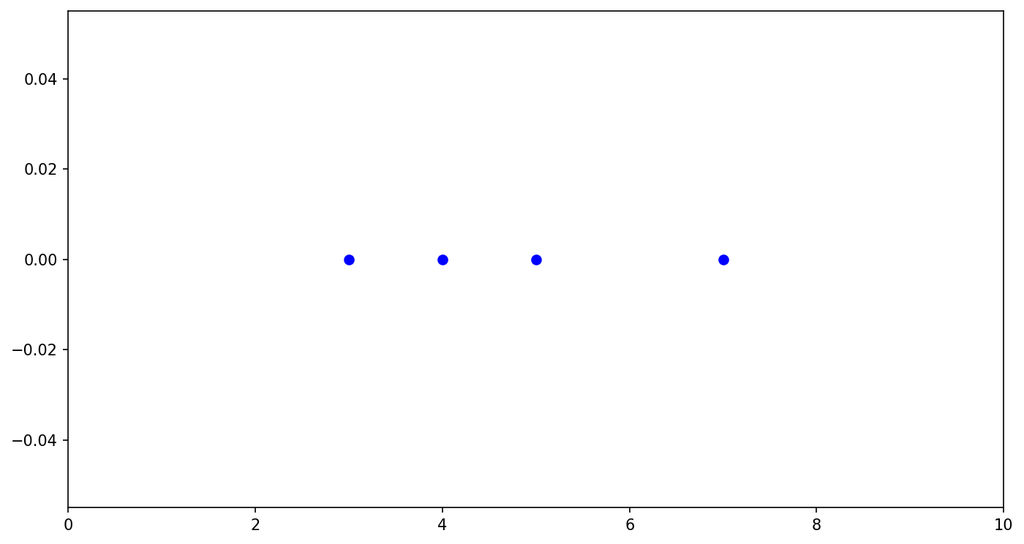

```python
import numpy as np
import matplotlib.pyplot as plt
%config InlineBackend.figure_format = 'png'
# Uncomment the following two lines to get large plots.
plt.rcParams['figure.figsize'] = (11, 6)
plt.rcParams['figure.dpi'] = 150

# Very few selected points.
b_1d = np.array([3, 4, 5, 7])
plt.plot(b_1d, np.zeros_like(b_1d), "bo");
plt.xlim(0,10);
```

...and search for the "least squares solution", i.e., the $x$ that has the smallest least squares distance from all $b_i$.:

$$x^*=\arg\min_{x\in\mathbb{R}} \sum_i (x-b_i)^2$$

That means, we have to vary $x\in\mathbb{R}$ until the sum becomes minimal.

The reason why we would want to do this may be e.g. that we want to find a maximum likelihood estimation of $x$, given linear measurements corrupted by Gaussian measurement errors.

So we sum up a set of quadratic functions $(x-b_i)^2$:

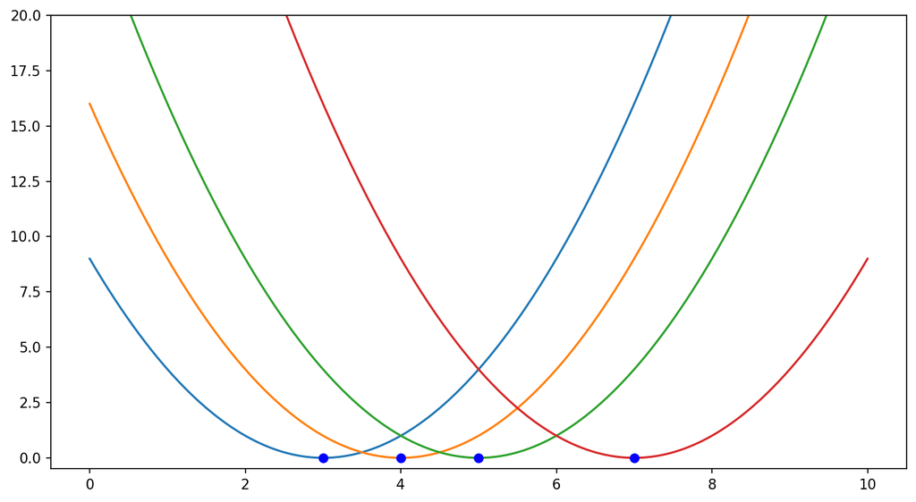

```python
x_vals_1d = np.linspace(0, 10, num=1000)
for b in b_1d: plt.plot(x_vals_1d, (x_vals_1d-b)**2)
plt.plot(b_1d, np.zeros_like(b_1d), "bo")
plt.ylim(-.5,20);
```

Maybe I could trick somebody to think the sum must have a complex shape, like this:

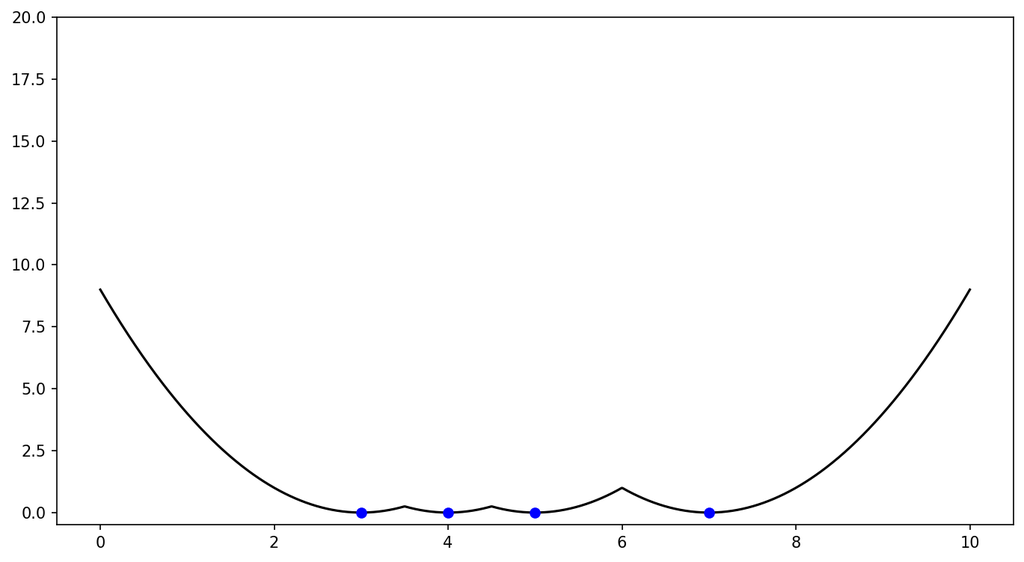

```python
plt.plot(x_vals_1d, ((x_vals_1d-b_1d[:,np.newaxis])**2).min(axis=0), "black")
plt.plot(b_1d, np.zeros_like(b_1d), "bo")
plt.ylim(-.5,20);
```

...but no, the sum is of course a *quadratic function*. It can't be otherwise, because adding up quadratic terms can't result in, say, cubic terms.

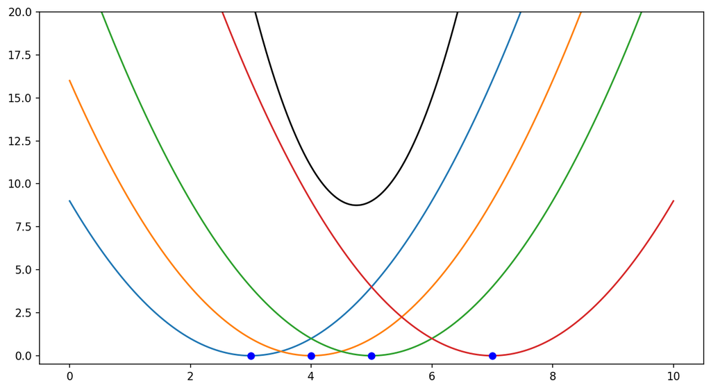

```python
for b in b_1d: plt.plot(x_vals_1d, (x_vals_1d-b)**2)
plt.plot(x_vals_1d, ((x_vals_1d-b_1d[:,np.newaxis])**2).sum(axis=0), "black")
plt.plot(b_1d, np.zeros_like(b_1d), "bo")
plt.ylim(-.5,20);
```

Since the sum is a quadratic function (with positive $x^2$ coefficients), it is of course also a **convex** function. Since the *domain* of $f(x)$ is *convex* (the full $\mathbb{R}$), and the *function* $f(x)$ itself is *convex*, the minimum can be found efficiently, for example, by "walking downhill".

In general, what we have here is a case of **convex optimization**, see e.g. Boyd and Vandenberghe (bibliography at end).

In this case, it is even easier, and we need not iteratively "walk downhill". The quadratic function has a global minimum where the gradient is zero. In 1D, the gradient is the derivative w.r.t. $x$, so $$f'(x)=\frac{d}{dx}\left(\sum_i (x-b_i)^2\right) = \sum_i 2(x-b_i).$$ Then, setting $\sum_i (x-b_i) = 0$ yields $mx - \sum_i b_i = 0$, so the result is the mean:

$$x^* = \frac{1}{m}\sum_i b_i.$$

In our example, the mean is:

```python
np.mean(b_1d)
```

```
4.75
```

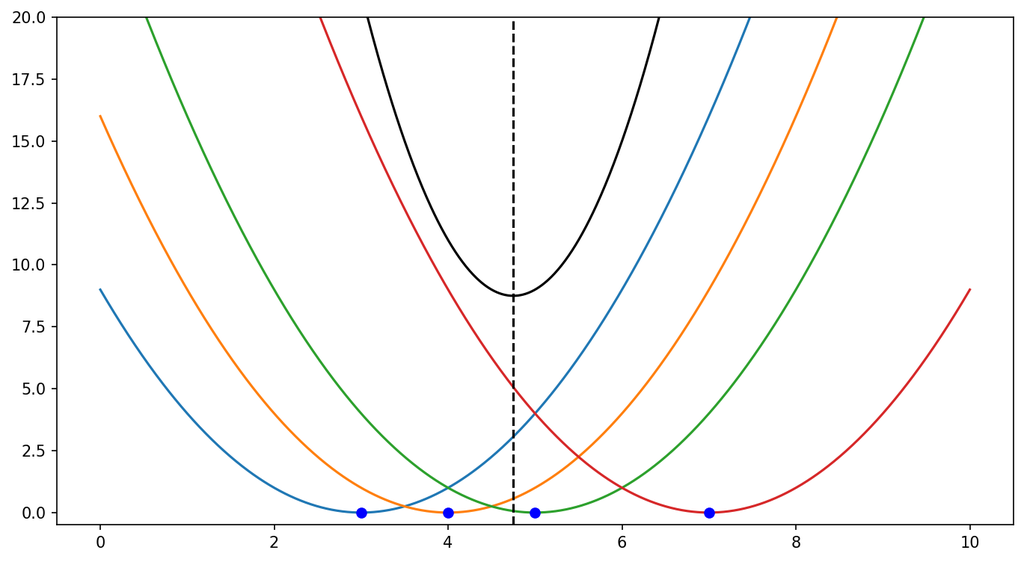

```python
for b in b_1d: plt.plot(x_vals_1d, (x_vals_1d-b)**2)
plt.plot(x_vals_1d, ((x_vals_1d-b_1d[:,np.newaxis])**2).sum(axis=0), "black")
plt.plot(b_1d, np.zeros_like(b_1d), "bo")
plt.axvline(x=np.mean(b_1d), c="k", ls="--")
plt.ylim(-.5,20);
```

The result is indicated by the dotted line. All this says is that the least squares estimate of $\mu$ is the mean, and the mean of this four numbers is this certain value.

However, if the task is to estimate an unknown value from measurements $b_i$, then it could be that the unknown value is $4$, and the measurement process added some noise, which has lead to the measurements $3$, $4$ and $5$, whereas the value $7$ is actually an outlier.

### Checking with random samples and outliers.

Let's say our measurement is normal distributed with $\mu=4$ and $\sigma=0.1$. (Note the points are all on a line. Some jitter in y is added for illustration only.)

```
inliers 30 outliers 0 mean 4.012
```

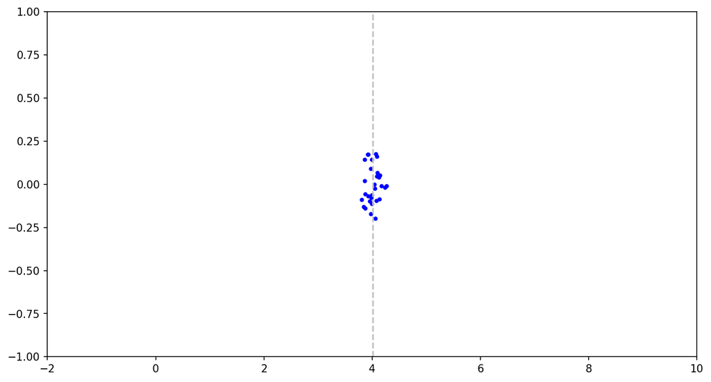

```python
rng = np.random.default_rng(12345)
n_1d_meas = 30
b_1d_meas = rng.normal(4, .1, n_1d_meas)

def report_mean(inliers, outliers):
    both = np.concatenate((inliers, outliers))
    plt.plot(inliers, rng.uniform(-.2,.2,len(inliers)), "b.")
    plt.plot(outliers, rng.uniform(-.2,.2,len(outliers)), "r.")
    plt.axvline(x=np.mean(both), c="silver", ls="--")
    plt.ylim(-1,1)
    plt.xlim(-2,10)
    print("inliers %d outliers %d mean %.3f" % (len(inliers), len(outliers), np.mean(both)))

report_mean(b_1d_meas, [])
```

Then, our mean works nicely as an estimator for $\mu$. Now if we have "outliers", which are uniformly distributed:

```
inliers 30 outliers 25 mean 3.511
```

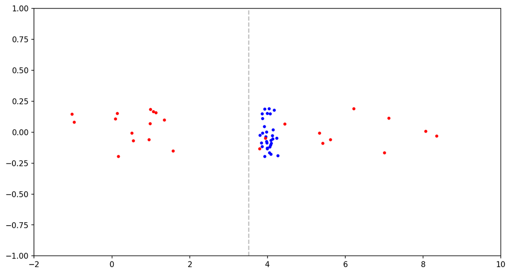

```python
n_1d_outl = 25
b_1d_outl = rng.uniform(-2,10,n_1d_outl)
report_mean(b_1d_meas, b_1d_outl)
```

We see that our estimator may be influenced by the outliers. In this case, the influence is not very large, since "data" and "outliers" both are centered at the same $\mu$.

A more realistic case could assume that all outliers are on one side. E.g., in Laserscanning, the measured ranges may be mostly too short, but (almost) never too long. So now, we assume the outliers are only to the right, uniformly distributed. In this "asymmetric" case we get a skewed overall distribution.

```
inliers 30 outliers 25 mean 5.285
```

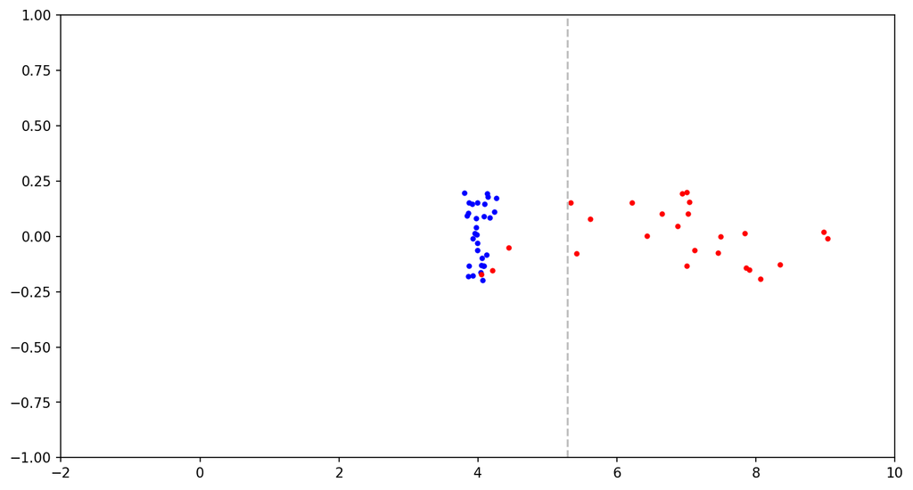

```python
b_1d_outl_a = np.abs(b_1d_outl-4)+4
report_mean(b_1d_meas, b_1d_outl_a)
```

## Least absolute deviations: the $l_1$ norm

In least squares, outliers have a large influence on the result, because the value added to the sum increases quadratically.

On can play with the function which "weights" how small and large deviations influence the estimation result. One can generalize

$$x^* = \arg\min_x \sum_i (x-b_i)^2$$

to $$x^* = \arg\min_x \sum_i \rho(x-b_i)$$

where $\rho(r)=r^2$ for the least squares case (define $r$ to be the residual, $r_i=(x-b_i)$). $\rho$ is called a **loss function** and these estimators are called **M-estimators**, see [@wikipedia](https://en.wikipedia.org/wiki/M-estimator).

For example, in order to make the influence of large values smaller, and small values larger, one can use the function $\rho(r)=|r|$, leading to:

$$x^* = \arg\min_x \sum_i |x-b_i|,$$

or in general, $$x^* = \arg\min_x ||Ax-b||_1.$$

For our initial 1D example, we now get:

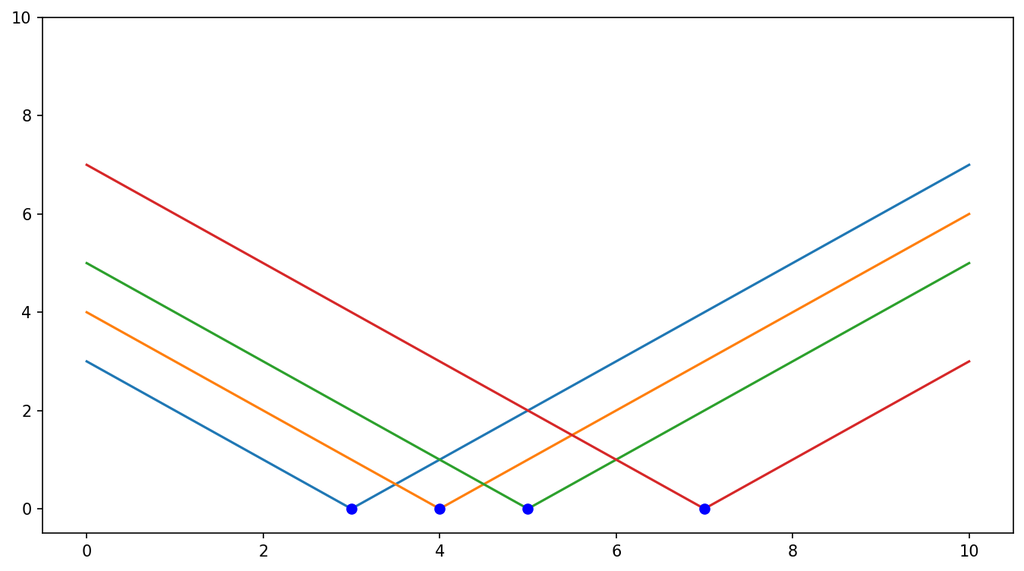

```python
for b in b_1d: plt.plot(x_vals_1d, np.abs(x_vals_1d-b))
plt.plot(b_1d, np.zeros_like(b_1d), "bo")
plt.ylim(-.5,10);
```

Now we can again guess the shape of the resulting sum. Will it be convex?

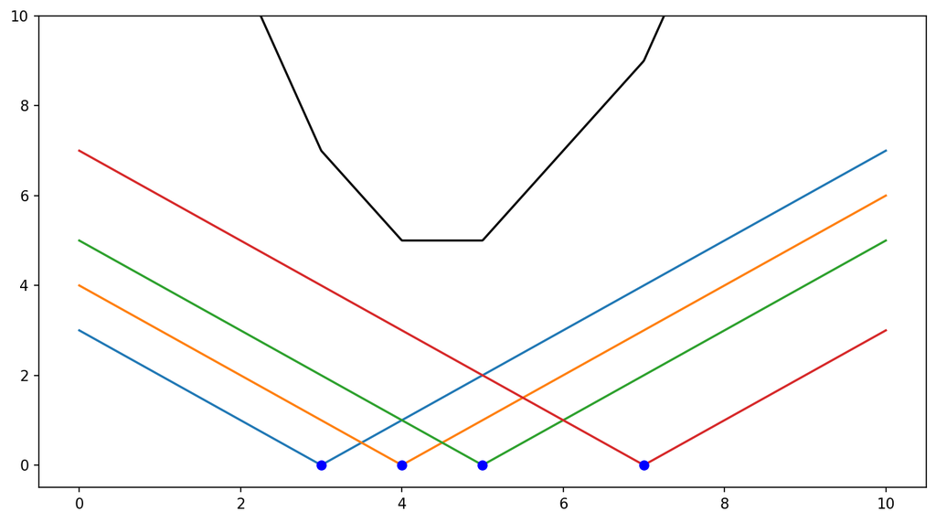

```python
for b in b_1d: plt.plot(x_vals_1d, np.abs(x_vals_1d-b))
plt.plot(x_vals_1d, (np.abs(x_vals_1d-b_1d[:,np.newaxis])).sum(axis=0), "black")
plt.plot(b_1d, np.zeros_like(b_1d), "bo")
plt.ylim(-.5,10);
```

It *is* convex. We could have known that beforehand, because $\rho(x)=|x|$ is convex, and *any nonnegative weighted sum of convex functions is convex* (see Boyd & Vandenberghe, sect. 3.2.1). So there is only one global minimum.

However, we see that there is a plateau between $b_1$ and $b_2$. So while there is a global minimum value, its location $x^*$ is not unique.

How can we find the minimum? We can walk downhill. Say, we start at 0, so we are in "the negative section" of all four curves, and the slope of the black curve must be $-4$. So walking downhill means, walking to the right. If we walk to the right, the next change will occur at $b_0$, where the slope of the corresponding $|x-b_0|$ curve changes from $-1$ to $+1$, so the slope of the black curve changes from $-4$ to $-2$. We continue to the right, and at $b_1$ the slope changes from $-2$ to $0$. We are at the global minimum.

If we think about it, we do not have to do all of this walking. For any given point $x$, all $b_i$ to the left of it contribute $+1$ to the slope, and all $b_i$ to the right of it contribute $-1$. So we have zero if the number of $b_i$ to the left and $b_i$ to the right are equal. Therefore, the least absolute deviations estimator is the median:

$$x^* = \mbox{median}_i(d).$$

If $m$, the number of observations $b_i$, is odd, the median will be in the central $b_{(m-1)/2}$, whereas if it is equal it is not uniquely defined, but usually, the mean between $b_{(m-2)/2}$ and $b_{(m-2)/2+1}$ is returned. For example, in numpy, we get the following (dotted black line):

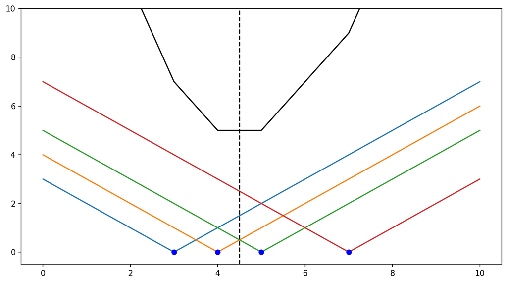

```python
for b in b_1d: plt.plot(x_vals_1d, np.abs(x_vals_1d-b))
plt.plot(x_vals_1d, (np.abs(x_vals_1d-b_1d[:,np.newaxis])).sum(axis=0), "black")
plt.plot(b_1d, np.zeros_like(b_1d), "bo")
plt.axvline(x=np.median(b_1d), c="k", ls="--")
plt.ylim(-.5,10);
```

### Checking with our 1D outlier example.

First, without outliers, the median works great.

```
inliers 30 outliers 0 mean 4.012 median 3.993
```

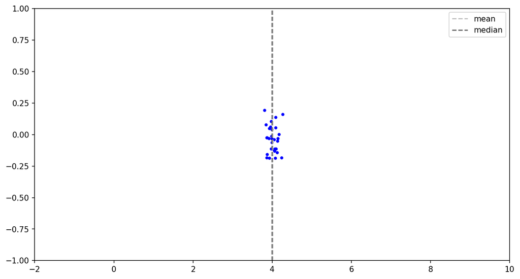

```python
def report_median(inliers, outliers):
    both = np.concatenate((inliers, outliers))
    plt.plot(inliers, rng.uniform(-.2,.2,len(inliers)), "b.")
    plt.plot(outliers, rng.uniform(-.2,.2,len(outliers)), "r.")
    plt.axvline(x=np.mean(both), c="silver", ls="--", label="mean")
    plt.axvline(x=np.median(both), c="dimgray", ls="--", label="median")
    plt.legend()
    plt.ylim(-1,1)
    plt.xlim(-2,10)
    print("inliers %d outliers %d mean %.3f median %.3f" %\
          (len(inliers), len(outliers), np.mean(both), np.median(both)))
report_median(b_1d_meas, [])
```

With our "symmetric outliers", we usually get a better result (dark gray line) than with the mean (light gray line). (But with the small number of samples used here, it depends a bit on the actual samples.)

```
inliers 30 outliers 25 mean 3.511 median 3.974
```

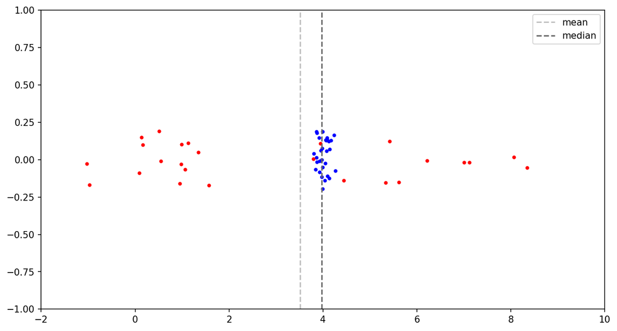

```python
report_median(b_1d_meas, b_1d_outl)
```

In the "asymmetric outlier" case, the median is much better, although it starts to walk away from the true value.

```
inliers 30 outliers 25 mean 5.285 median 4.140
```

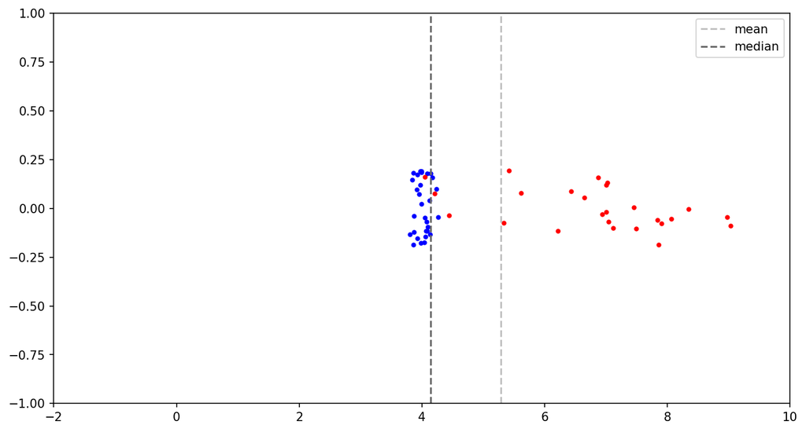

```python
report_median(b_1d_meas, b_1d_outl_a)
```

However, if we have even more outliers, we get:

```
inliers 30 outliers 60 mean 5.858 median 5.029
```

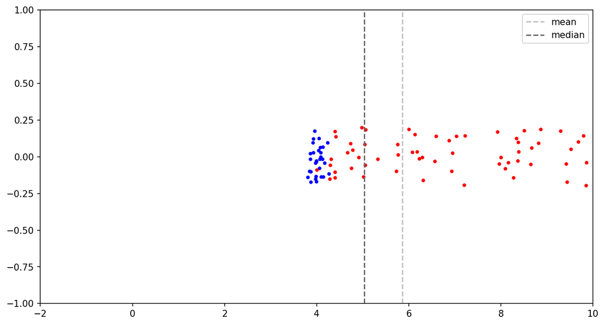

```python
n_1d_more_outl = 2*n_1d_meas
b_1d_more_outl_a = rng.uniform(4, 10, n_1d_more_outl)
report_median(b_1d_meas, b_1d_more_outl_a)
```

Intuitively, for each two more outliers to the right, the median will "walk one $b_i$ to the right", no matter how far away the added outlier to the right actually is.

## Maximum Consensus: maximizing inliers, or minimizing outliers

Now we have seen that the $l_1$ norm is more robust than the $l_2$ norm. Intuitively, with the $l_2$ norm, the actual value of the outlier plays a role. The larger it is, the more it pulls $x^*$ towards it.

In contrast, with the $l_1$ norm, each outlier only "counts", independently of its actual value. If there are many inliers and only a few outliers, they will be unable to worsen the estimate substantially, no matter how far away they are from the true value.

But if the number of outliers gets very large, the $l_1$ norm will walk away from the true solution, especially if the outliers are not "symmetric" around the true value. (Only the difference count between "left" and "right" outliers plays a role -- two more "right" outliers than "left" outliers make the median walk one to the right.) In order to further reduce the influence of outliers, we could try to discard them altogether.

The idea of **maximum consensus** is to define an "acceptance range" $[-\varepsilon, \varepsilon]$ inside which an observation counts as inlier, otherwise it is an outlier. The goal is then to find the parameters $x^*$ which maximize the number of inliers. To formulate this, the indicator function $\mathbb{1}(\cdot)$ is typically used, where $\mathbb{1}(c)$ is 1 if condition $c$ is true, and 0 otherwise. Then, the maximum consensus goal can be formulated as

$$x^* = \arg\max_x \sum_i \mathbb{1}\left( |x-b_i| \leq \varepsilon \right),$$

i.e., we are counting the inliers, $+1$ if inside, and $0$ if outside.

However, to make it fit a bit more to our previous considerations, we can define it the opposite way: we count the outliers, i.e. $0$ if inside, and $+1$ if outside. Thus, we can achieve our goal by defining the *loss function*

$$\rho(r) = \left\{ \begin{matrix}0&\mbox{for}&|r|\leq\varepsilon\\1&\mbox{else.}\end{matrix}\right.$$

Here is a comparison of loss functions $\rho(r)$ we used so far:

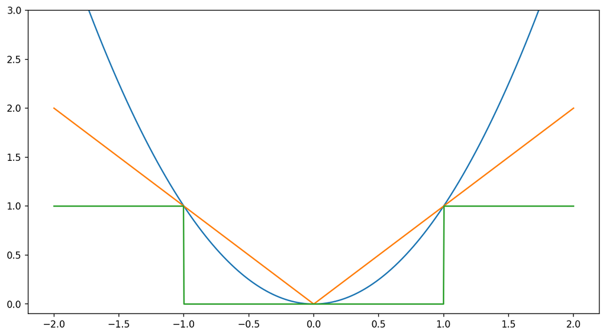

```python
# This is our new rho function.
def rho_1d(r, eps):
    return (np.abs(r)>eps).astype(float)

x_comparison = np.linspace(-2,2,1000)
plt.plot(x_comparison, x_comparison**2)
plt.plot(x_comparison, np.abs(x_comparison))
plt.plot(x_comparison, rho_1d(x_comparison, 1))
plt.ylim(-.1,3);
```

While we flattened the curve outside, we notice it is **not convex** anymore. This brings with it substantial trouble, as we will see. Because we hypothesized above that $4$ may be the correct value and $3$ and $5$ are still to be considered as inliers as well we will use $\varepsilon=1.2$.

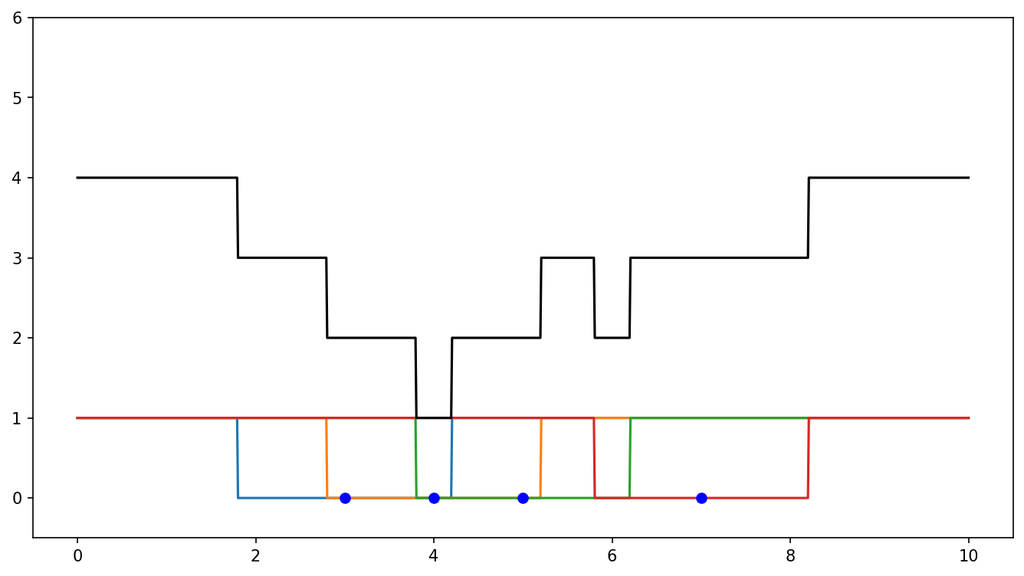

```python
eps_1d = 1.2
for b in b_1d: plt.plot(x_vals_1d, rho_1d(x_vals_1d-b, eps_1d))
plt.plot(x_vals_1d, (rho_1d(x_vals_1d-b_1d[:,np.newaxis], eps_1d)).sum(axis=0), "black")
plt.plot(b_1d, np.zeros_like(b_1d), "bo")
plt.ylim(-.5,6);
```

The result has its minimum at the "right" location. It is a plateau, as in the $l_1$ case. However, as the single functions are not convex, their sum is neither. Apart from having steps, it has local minima. And of course, some of them may be identical to the global minimum, as shown in this example with two more points.

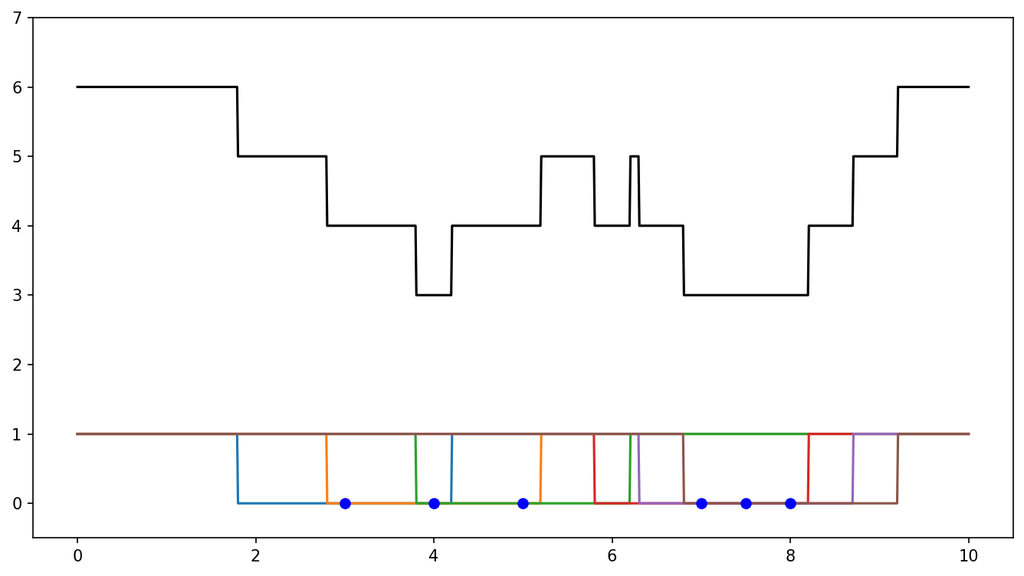

```python
b_1d_more = np.array([3,4,5,7,7.5,8])
for b in b_1d_more: plt.plot(x_vals_1d, rho_1d(x_vals_1d-b, eps_1d))
plt.plot(x_vals_1d, (rho_1d(x_vals_1d-b_1d_more[:,np.newaxis], eps_1d)).sum(axis=0), "black")
plt.plot(b_1d_more, np.zeros_like(b_1d_more), "bo")
plt.ylim(-.5,7);
```

### Programming a function to find the consensus.

In the least squares case, we could use $x^*=$ `mean()`, in the $l_1$ case, $x^*=$ `median()`, but the maximum consensus case is less clear.

The most obvious idea is to use a "sweep type" algorithm:

- sweep the real line from left to right
- at each $b_i-\varepsilon$ ("interval start"), decrease the total score by 1
- at each $b_i+\varepsilon$ ("interval end"), increase the total score by 1
- computing the cumulative sum, one can find the global minimum
- for now, if there are several minima, just return one of them
- to make it look nicer, return the "center of the plateau" (similar to the median case with an even number of values).

```python
def cons_1d(b_vals, eps):
    # Note tuple sort will always place the -1 event in front of the +1 event
    # so the "less or equal" is implemented correctly if events coincide.
    events = sorted([(b-eps,-1) for b in b_vals]+[(b+eps,1) for b in b_vals])
    score = np.cumsum(np.array([e[1] for e in events]))
    xs = np.argmin(score)  # Get one of the minima.
    return (events[xs][0]+events[xs+1][0])/2  # Return the center of the plateau.
```

Check for our simple 1D example:

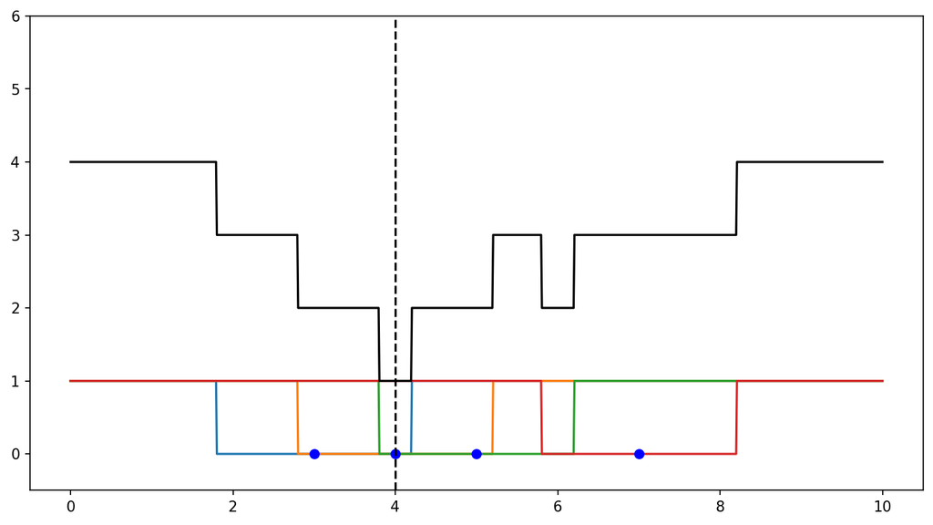

```python
for b in b_1d: plt.plot(x_vals_1d, rho_1d(x_vals_1d-b, eps_1d))
plt.plot(x_vals_1d, (rho_1d(x_vals_1d-b_1d[:,np.newaxis], eps_1d)).sum(axis=0), "black")
plt.plot(b_1d, np.zeros_like(b_1d), "bo")
plt.axvline(x=cons_1d(b_1d, eps_1d), c="k", ls="--")
plt.ylim(-.5,6);
```

### Checking with the 1D random samples.

Since we assumed our original signal to be normal distributed with $\sigma=0.1$, we could set $\varepsilon=2\cdot\sigma=0.2$.

```
inliers 30 outliers 0 mean 4.012 median 3.993 consensus 3.989
```

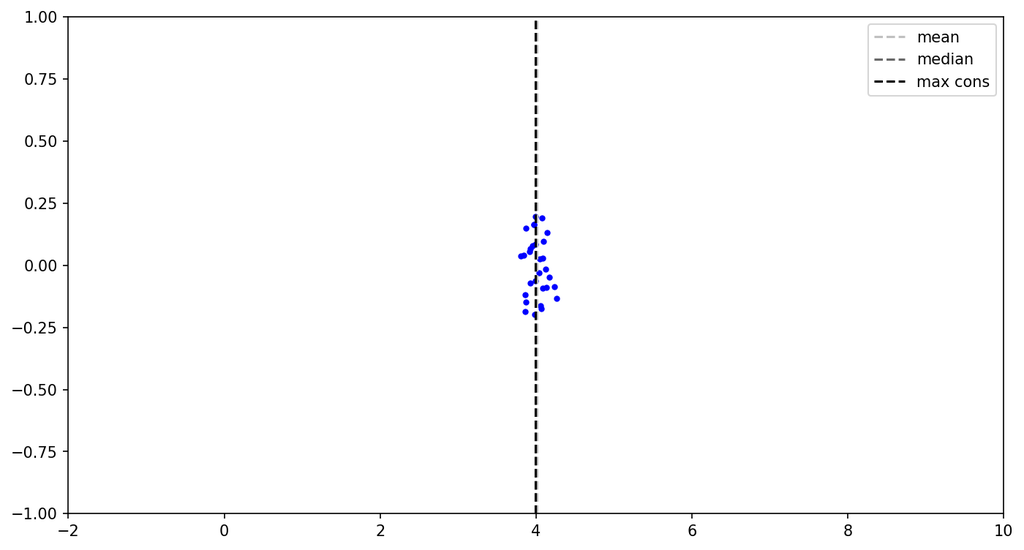

```python
eps_1d_random = 0.2
def report_cons(inliers, outliers, eps):
    both = np.concatenate((inliers, outliers))
    plt.plot(inliers, rng.uniform(-.2,.2,len(inliers)), "b.")
    plt.plot(outliers, rng.uniform(-.2,.2,len(outliers)), "r.")
    plt.axvline(x=np.mean(both), c="silver", ls="--", label="mean")
    plt.axvline(x=np.median(both), c="dimgray", ls="--", label="median")
    plt.axvline(x=cons_1d(both, eps), c="black", ls="--", label="max cons")
    plt.legend()
    plt.ylim(-1,1)
    plt.xlim(-2,10)
    print("inliers %d outliers %d mean %.3f median %.3f consensus %.3f" %\
          (len(inliers), len(outliers), np.mean(both), np.median(both),
           cons_1d(both, eps_1d_random)))
report_cons(b_1d_meas, [], eps_1d_random)
```

So, looks good with no noise. Now, for "symmetric" noise:

```
inliers 30 outliers 25 mean 3.511 median 3.974 consensus 3.983
```

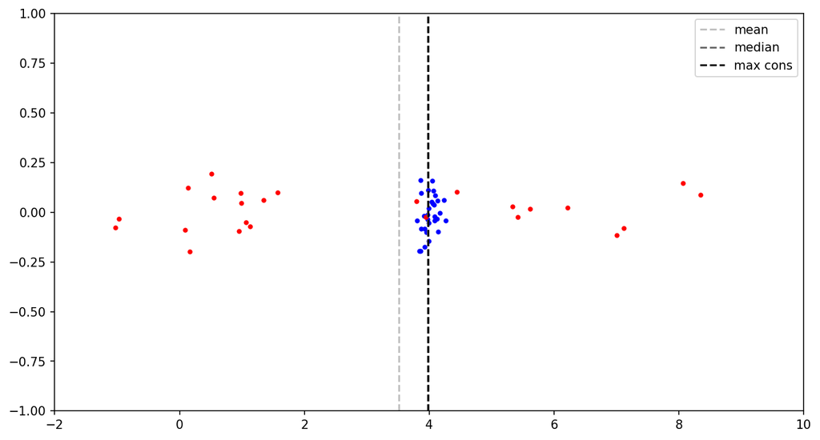

```python
report_cons(b_1d_meas, b_1d_outl, eps_1d_random)
```

...looks good, too. For the asymmetric case:

```
inliers 30 outliers 25 mean 5.285 median 4.140 consensus 4.036
```

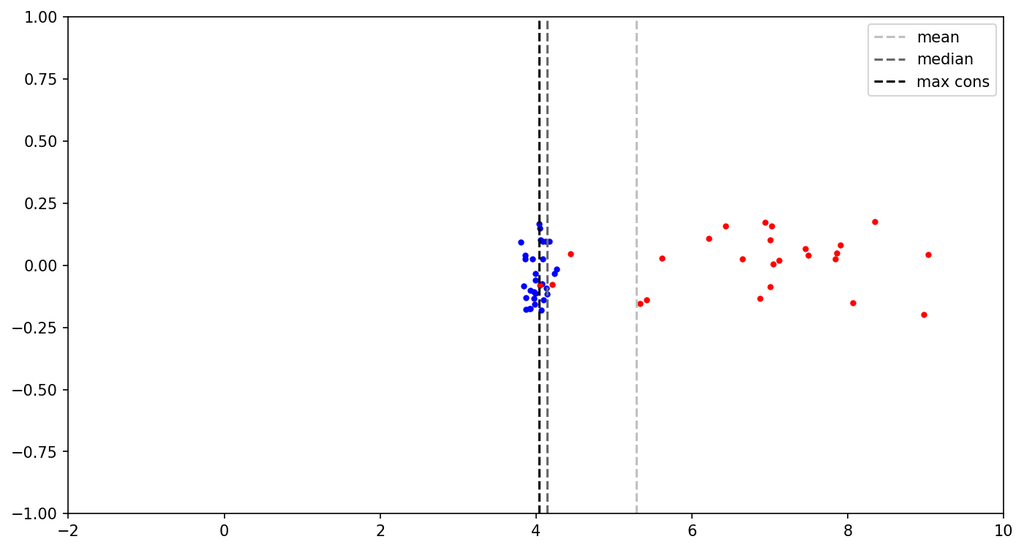

```python
report_cons(b_1d_meas, b_1d_outl_a, eps_1d_random)
```

...looks still good. Now, for the case with the large amount of outliers:

```
inliers 30 outliers 60 mean 5.858 median 5.029 consensus 3.989
```

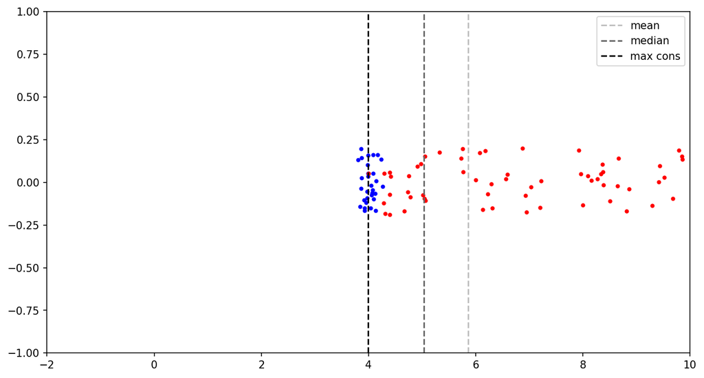

```python
report_cons(b_1d_meas, b_1d_more_outl_a, eps_1d_random)
```

...the maximum consensus occurs close to $4$. That is pretty impressive, given that we have twice as many outliers than inliers.

In order to figure out "how sure" we are about the maximum consensus, or the minimum in our score, we can plot the score over the entire range.

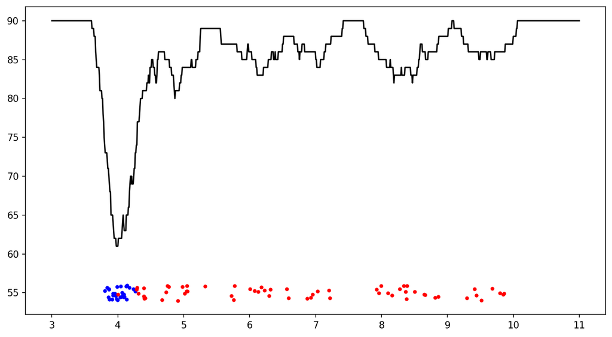

```python
x_vals_mc = np.linspace(3,11,1000)
all_b = np.concatenate((b_1d_meas, b_1d_more_outl_a))
vals = np.sum([rho_1d(x_vals_mc - b, eps_1d_random) for b in all_b], axis=0)
plt.plot(b_1d_meas, rng.uniform(-1,1,len(b_1d_meas))+55, "b.")  # +55 just for nice plot.
plt.plot(b_1d_more_outl_a, rng.uniform(-1,1,len(b_1d_more_outl_a))+55, "r.")
plt.plot(x_vals_mc, vals, c="k");
```

# Fitting a model - the multidimensional case

## Least squares estimation for the line

To illustrate, we will estimate a line. Our true line is $y = 0.5\cdot x + 2$, but in order to escape notational clashes, we will use $(p,q)$ for the coordinates, so $q = 0.5 \cdot p + 2$.

In least squares, we generally want to find

$$x^* = \arg\min_{x}|| Ax - b ||_2^2.$$

where $x$ is the vector of unknowns. If we compute the gradient and set it to zero, similar to what we did in the 1D case above, we will get the well-known solution

$$x^* = (A^\top A)^{-1} A^\top b$$

(see e.g. chapter 3 in Hastie et al.). Note that $x$ are our unknowns to be estimated, not the $x$-values along the $x$-axis. That is, $x=(x_0, x_1)^\top = (\mbox{intercept},\mbox{slope})^\top$. Whereas for the points, let us say the point coordinates are $P_i = (p_i, q_i)$.

For a given value $p_i$, along the horizontal axis, the line with intercept $x_0$ and slope $x_1$ has the value $x_1\cdot p_i + x_0$, while the value of the point is $q_i$. So the residual vector is:

$$ r = Ax-b = \begin{bmatrix}1&p_0\\ 1&p_1\\ \vdots & \vdots\\ 1&p_{m-1} \end{bmatrix}\cdot \begin{bmatrix}x_0\\x_1\end{bmatrix} - \begin{bmatrix}q_0\\q_1\\ \vdots \\q_{m-1}\end{bmatrix} $$

and we minimize $||r||_2^2$. Note that $r_i$ is not the perpendicular distance, but rather the ($q$-) axis parallel distance. Instead of $(A^\top A)^{-1} A^\top$ one typically uses the [pseudoinverse](https://en.wikipedia.org/wiki/Moore%E2%80%93Penrose_inverse) which is typically available as `pinv` (note that although we do it here, one does not have to compute the inverse to solve the equation system).

### First, introduce the data

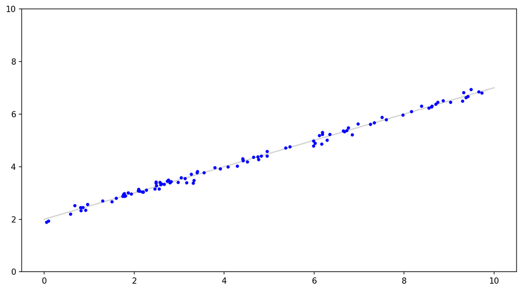

```python
# This line is our true model.
def line(x):
    return 0.5*x + 2

# Generate samples: uniform along x, and for each x, additive Gaussian "measurement" noise.
rng = np.random.default_rng(12345) # Restart.
x_2d_vals = np.linspace(0, 10, num=100)
n_2d_meas = 100
inliers_x = rng.uniform(0,10,n_2d_meas)
inliers_y = line(inliers_x) + rng.normal(0,0.1,n_2d_meas)
inliers = np.vstack((inliers_x, inliers_y)).T

plt.plot(x_2d_vals, line(x_2d_vals), c="lightgray")
plt.plot(inliers[:,0], inliers[:,1], "b.")
plt.ylim(0,10);
```

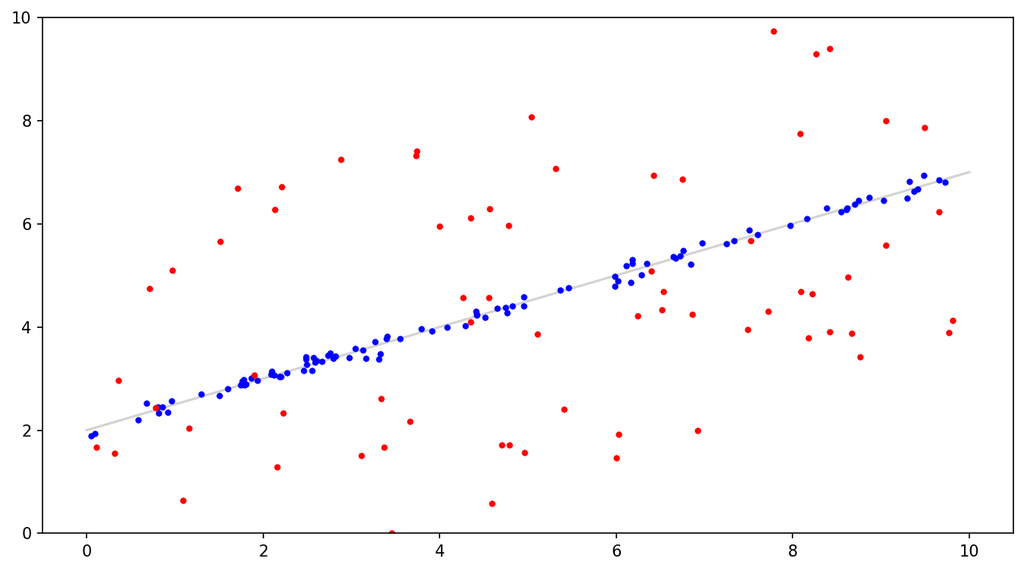

```python
# "Symmetric outliers": uniform samples.
n_2d_outliers = 70
outliers_x = rng.uniform(0,10,n_2d_outliers)
outliers_y = line(outliers_x) + rng.uniform(-4,4,n_2d_outliers)
outliers = np.vstack((outliers_x, outliers_y)).T
plt.plot(x_2d_vals, line(x_2d_vals), c="lightgray")
plt.plot(inliers[:,0], inliers[:,1], "b.")
plt.plot(outliers[:,0], outliers[:,1], "r.")
plt.ylim(0,10);
```

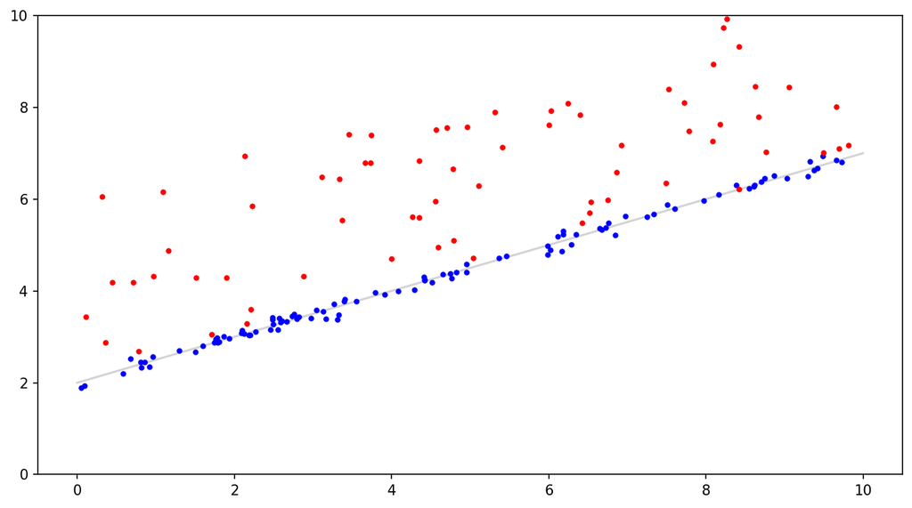

```python
# "Asymmetric outliers": uniform samples, all above.
outliers_a_y = line(outliers_x) + rng.uniform(0,4,n_2d_outliers)
outliers_a = np.vstack((outliers_x, outliers_a_y)).T
plt.plot(x_2d_vals, line(x_2d_vals), c="lightgray")
plt.plot(inliers[:,0], inliers[:,1], "b.")
plt.plot(outliers_a[:,0], outliers_a[:,1], "r.")
plt.ylim(0,10);
```

### Now, the estimation results for the least squares case.

First, let us see the solution for the system without outliers.

```
intercept 1.995 slope 0.502
```

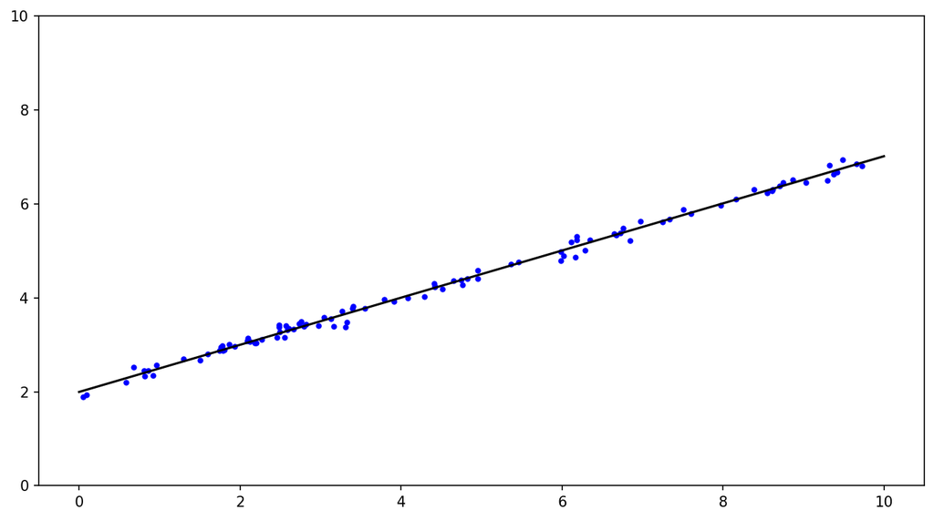

```python
def report_l2(inl, outl):
    both = np.concatenate((inl, outl))  # (m x 2) matrix of all point coordinates.

    # Estimate.
    A = np.vstack((np.ones(both.shape[0]), both[:,0])).T
    intercept, slope = np.linalg.pinv(A) @ both[:,1]

    # Report.
    print("intercept %.3f slope %.3f" % (intercept, slope))
    plt.plot(x_2d_vals, line(x_2d_vals), c="lightgray")
    plt.plot(inl[:,0], inl[:,1], "b.")
    plt.plot(outl[:,0], outl[:,1], "r.")
    plt.plot(x_2d_vals, slope*x_2d_vals+intercept, c="k")
    plt.ylim(0,10)

report_l2(inliers,np.empty((0,2)))
```

Now, with "symmetric" outliers.

```
intercept 2.231 slope 0.443
```

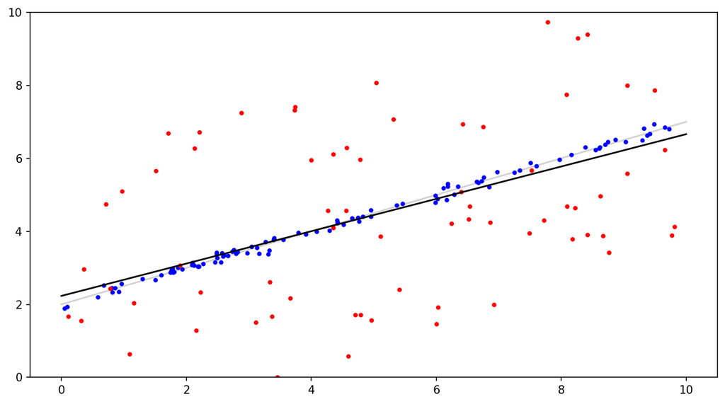

```python
report_l2(inliers, outliers)
```

And with "asymmetric" outliers:

```
intercept 2.643 slope 0.530
```

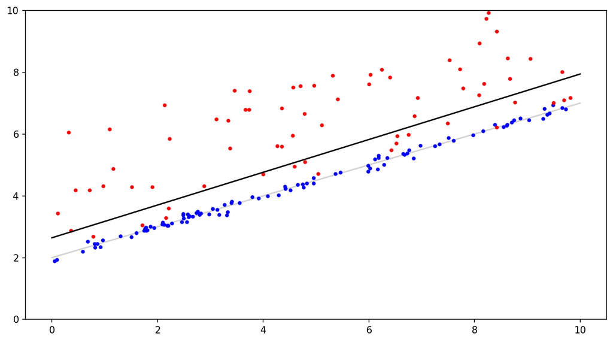

```python
report_l2(inliers, outliers_a)
```

This was as expected. The symmetric noise had a relatively small impact, but with all outliers above the line, the result was substantially shifted.

## Least absolute deviations for the line

Now it gets more interesting. Remember, we now have to do a $l_1$-norm minimization:

$$x^* = \arg\min_x || Ax - b ||_1,$$

which is exactly the same as

$$x^* = \arg\min_x \sum_{i=0}^{m-1} |a_i^\top x-b_i|,$$

were $a_i^\top$ is the $i$-th row vector of $A$.

How can we find this minimum? Being a sum of absolute values, the function is not differentiable. It is also not linear. However, since $|\cdot|$ is a *convex function*, the *sum is convex*, too. So even though there is no closed-form solution, we know we can solve the problem efficiently.

We can re-formulate the goal. Instead of $ \min_x \sum_{i=0}^{m-1} |a_i^\top x-b_i|$ we write

$$ \min_{s,x} \sum_{i=0}^{m-1} s_i,$$

subject to

$$ | a_i^\top x - b_i | \leq s_i .$$

We can get rid of the absolute value by doubling the number of conditions,

$$ \begin{matrix} \phantom{-}(a_i^\top x - b_i) & \leq & s_i & \mbox{and}\\ -(a_i^\top x - b_i) & \leq & s_i, & \\ \end{matrix} $$

and so, overall the problem is of the form

$$ \begin{array}{rl} \mbox{minimize the value of:} & c^\top x' \\ \mbox{among all $x\in\mathbb{R}$ satisfying:} & A' x' \leq b' \end{array}$$

where $x'$, $A'$ and $b'$ are formed from the above entities and "$\leq$" between vectors is understood componentwise.